# ScPCA Supplemental cell type report for SCPCL000022

Childhood Cancer Data Lab

2024-11-05

This report contains a summary of cell type annotation results for library SCPCL000022. The goal of this report is to provide more detailed information about cell type annotation results as an initial evaluation of their quality and reliability.

Performing cell type annotation is an inherently challenging task with high levels of uncertainty, especially when using automated annotation methods. One way to address this is to use multiple cell type annotation approaches and compare the results, as we have begun to do in this report.

When multiple methods annotate a given cell as the same or similar cell type, this may qualitatively indicate a more robust annotation.

Note that the contents of this report will vary based on which cell type annotations are present. Further, be aware that different cell type annotation methods may assign different labels to the same or similar cell type (e.g., the different string representations `B cell naive` and `Naive B cell`), due to use of different underlying reference datasets. Please note that all cell type annotation reference datasets are derived from normal (not tumor) tissue.

**This library contains the following cell type annotations:**

- Annotations from [`SingleR`](https://bioconductor.org/packages/release/bioc/html/SingleR.html), a reference-based approach ([Looney *et al.* 2019](https://doi.org/10.1038/s41590-018-0276-y)). The `BlueprintEncodeData` dataset, obtained from the [`celldex` package](http://bioconductor.org/packages/release/data/experiment/html/celldex.html), was used for reference annotations.
- Annotations from [`CellAssign`](https://github.com/Irrationone/cellassign), a marker-gene-based approach ([Zhang *et al.* 2019](https://doi.org/10.1038/s41592-019-0529-1)). Marker genes for cell types were obtained from [PanglaoDB](https://panglaodb.se/) and compiled into a reference named `brain-compartment`. This reference includes the following organs and tissue compartments: brain, embryo, immune system, and vasculature.

# Sample metadata

The below table summarizes clinical metadata for the sample associated with this library. Blue hyperlinks are present for any terms with an ontology term identifier associated with the displayed human readable value. These links will direct you to a web page with information about that ontology term identifier.

| Sample ID | SCPCS000022 |
| --- | --- |
| Diagnosis | [Glioblastoma](http://purl.obolibrary.org/obo/MONDO_0018177) |
| Subdiagnosis | Epithelioid/giant cell |
| Tissue location | [3rd/lateral ventricles, pineal](http://purl.obolibrary.org/obo/UBERON_0000955) |
| Disease timing | Initial diagnosis |
| Age | [15](http://purl.obolibrary.org/obo/HsapDv_0000109) |
| Sex | [F](http://purl.obolibrary.org/obo/PATO_0000383) |
| Organism | [Homo sapiens](http://purl.obolibrary.org/obo/NCBITaxon_9606) |
| Sample type | patient tissue |

# Cell type Annotation Summary

The plots and tables included here detail the results from performing cell type annotation.

## Statistics

### `SingleR` cell type annotations

In this table, cells labeled “Unknown cell type” are those which `SingleR` pruned due to low-quality assignments. In the processed result files, these cells are labeled `NA`.

| Annotated cell type | Number of cells | Percent of cells |
| --- | --- | --- |
| macrophage | 243 | 53.76% |
| monocyte | 41 | 9.07% |
| effector memory CD4-positive, alpha-beta T cell | 19 | 4.2% |
| effector memory CD8-positive, alpha-beta T cell | 15 | 3.32% |
| natural killer cell | 14 | 3.1% |
| astrocyte | 12 | 2.65% |
| mesangial cell | 10 | 2.21% |
| neuron | 10 | 2.21% |
| central memory CD4-positive, alpha-beta T cell | 9 | 1.99% |
| regulatory T cell | 6 | 1.33% |
| dendritic cell | 5 | 1.11% |
| class switched memory B cell | 4 | 0.88% |
| melanocyte | 4 | 0.88% |
| CD4-positive, alpha-beta T cell | 3 | 0.66% |
| central memory CD8-positive, alpha-beta T cell | 3 | 0.66% |
| epithelial cell | 2 | 0.44% |
| fat cell | 2 | 0.44% |
| fibroblast | 2 | 0.44% |
| muscle cell | 2 | 0.44% |
| naive B cell | 2 | 0.44% |
| cell of skeletal muscle | 1 | 0.22% |
| chondrocyte | 1 | 0.22% |
| common lymphoid progenitor | 1 | 0.22% |
| hematopoietic multipotent progenitor cell | 1 | 0.22% |
| hematopoietic stem cell | 1 | 0.22% |
| megakaryocyte-erythroid progenitor cell | 1 | 0.22% |
| memory B cell | 1 | 0.22% |
| plasma cell | 1 | 0.22% |
| Unknown cell type | 36 | 7.96% |

### `CellAssign` cell type annotations

In this table, cells labeled “Unknown cell type” are those which `CellAssign` could not confidently assign to a label in the reference list. In the processed result files, these cells are labeled `"other"`.

| Annotated cell type | Number of cells | Percent of cells |
| --- | --- | --- |
| Dendritic cells | 319 | 70.58% |
| T cells | 51 | 11.28% |
| NK cells | 20 | 4.42% |
| Bergmann glia | 19 | 4.2% |
| Astrocytes | 9 | 1.99% |
| B cells | 6 | 1.33% |
| Meningeal cells | 4 | 0.88% |
| T memory cells | 3 | 0.66% |
| B cells naive | 2 | 0.44% |
| Mast cells | 2 | 0.44% |
| Monocytes | 2 | 0.44% |
| Pyramidal cells | 2 | 0.44% |
| Red pulp macrophages | 2 | 0.44% |
| Schwann cells | 2 | 0.44% |
| Dopaminergic neurons | 1 | 0.22% |
| Gamma delta T cells | 1 | 0.22% |
| Natural killer T cells | 1 | 0.22% |
| Neural stem/precursor cells | 1 | 0.22% |
| Neurons | 1 | 0.22% |
| Noradrenergic neurons | 1 | 0.22% |
| Plasma cells | 1 | 0.22% |
| Unknown cell type | 2 | 0.44% |

## UMAPs

In this section, we show UMAPs colored by clusters. Clusters were calculated using the graph-based Louvain algorithm with Jaccard weighting.

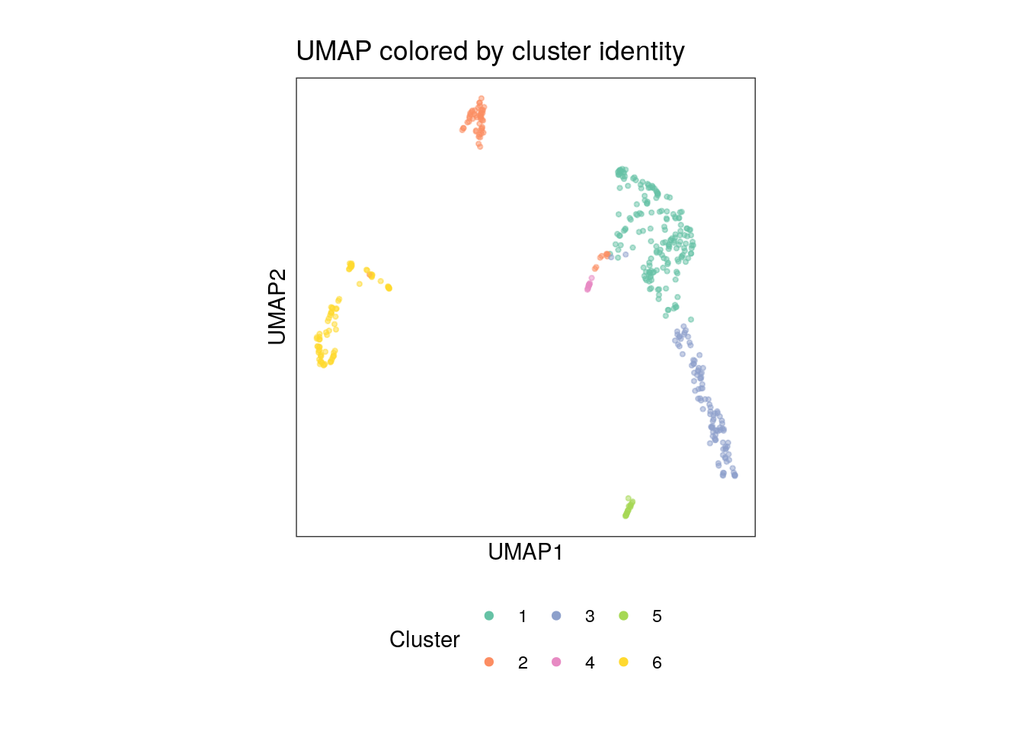

Next, we show UMAPs colored by cell types. For each cell typing method, we show a separate faceted UMAP. In each panel, cells that were assigned the given cell type label are colored, while all other cells are in grey.

For legibility, only the seven most common cell types are shown. All other cell types are grouped together and labeled “All remaining cell types” (not to be confused with “Unknown cell type” which represents cells that could not be classified).

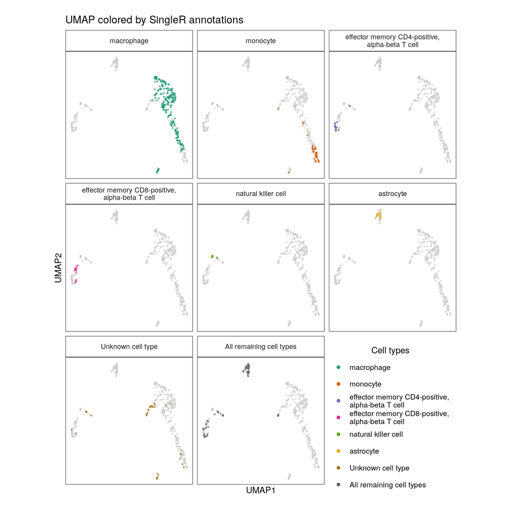

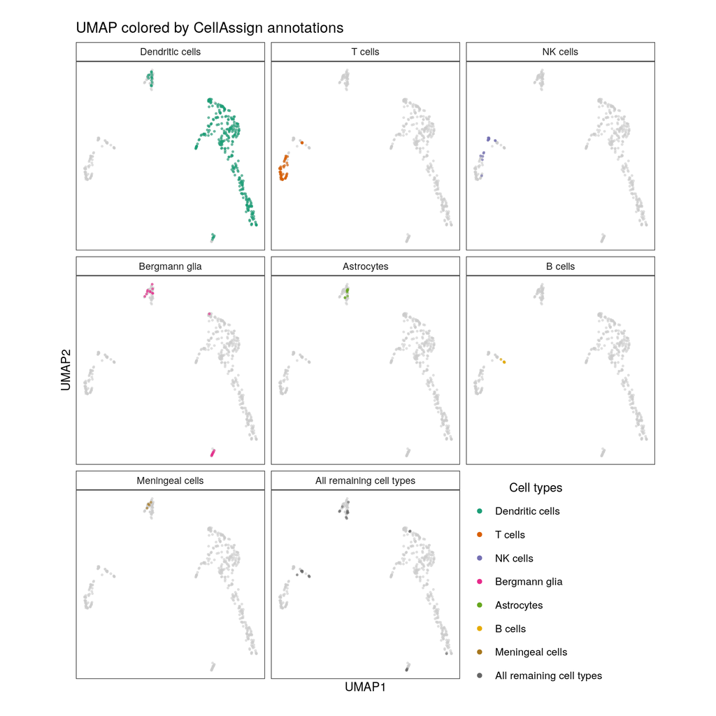

# Cell label comparison plots

This section displays heatmaps comparing cell labels from various methods.

We use the [Jaccard similarity index](https://en.wikipedia.org/wiki/Jaccard_index) to display the agreement between between pairs of labels assigned by different annotation methods.

The Jaccard index reflects the degree of overlap between the two labels and ranges from 0 to 1.

- If the labels are assigned to identical sets of cells, the Jaccard index will be 1.
- If the labels are assigned to completely non-overlapping sets of cells, the Jaccard index will be 0.

High agreement between methods qualitatively indicates higher confidence in the cell type annotation.

## Unsupervised clustering

Here we show the labels from unsupervised clustering compared to cell type annotations. Cluster assignment was performed using the `Louvain` algorithm.

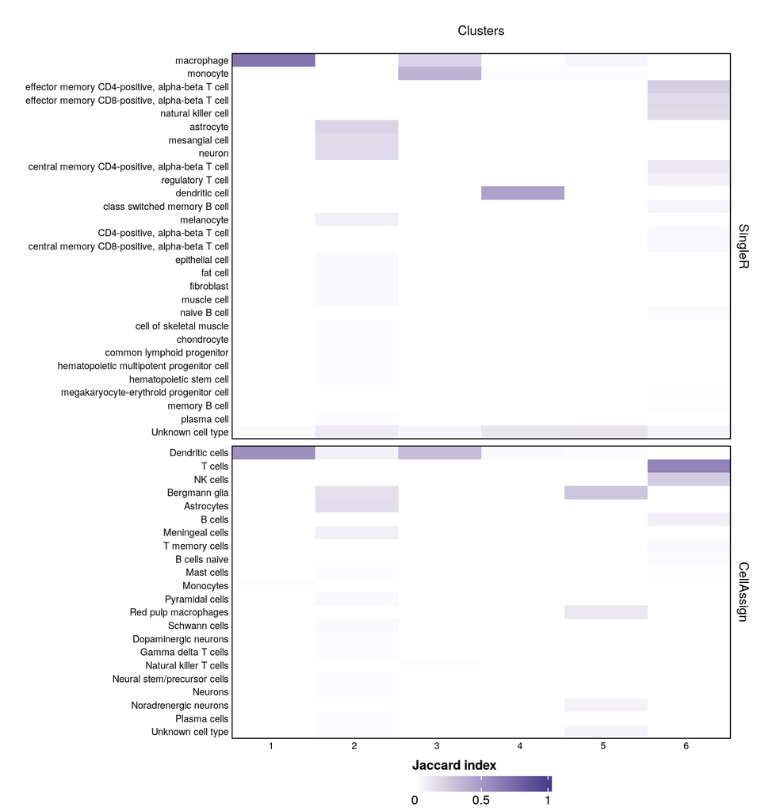

## Automated annotations

This section displays a heatmap directly comparing `SingleR` and `CellAssign` cell type annotations. Note that due to different annotations references, these methods may use different names for similar cell types.

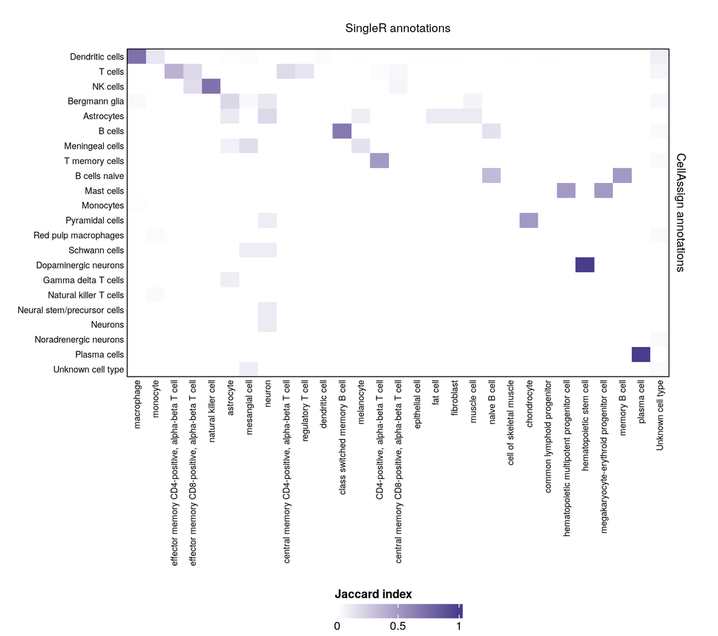

# Quality assessments of automated annotations

## `SingleR` annotations

To assess the quality of `SingleR` cell type annotations, we use the delta median statistic.

- Delta median is calculated for each cell as the difference between the `SingleR` score of the annotated cell type label and the median score of the other cell type labels in the reference dataset.
- Higher delta median values indicate higher quality cell type annotations.
  - Values can range from 0-1.
  - Note that there is no universal threshold for calling absolute high vs. low quality, as described in the [`SingleR` book section on ‘Annotation diagnostics’](https://bioconductor.org/books/release/SingleRBook/annotation-diagnostics.html#annotation-diagnostics).

You can interpret this plot as follows:

- Each point represents the delta median statistic of a given cell whose `SingleR` annotation is shown on the y-axis.
- The point style indicates `SingleR`’s quality assessment of the annotation:
  - High-quality cell annotations are shown as closed points.
  - Low-quality cell annotations are shown as open points. In other sections of this report, these cells are labeled as `Unknown cell types`.
  - For more information on how `SingleR` calculates annotation quality, please refer to [this `SingleR` documentation](https://rdrr.io/bioc/SingleR/man/pruneScores.html).
- Diamonds represent the median of the delta median statistic specifically among high-quality annotations for the given cell type annotation.

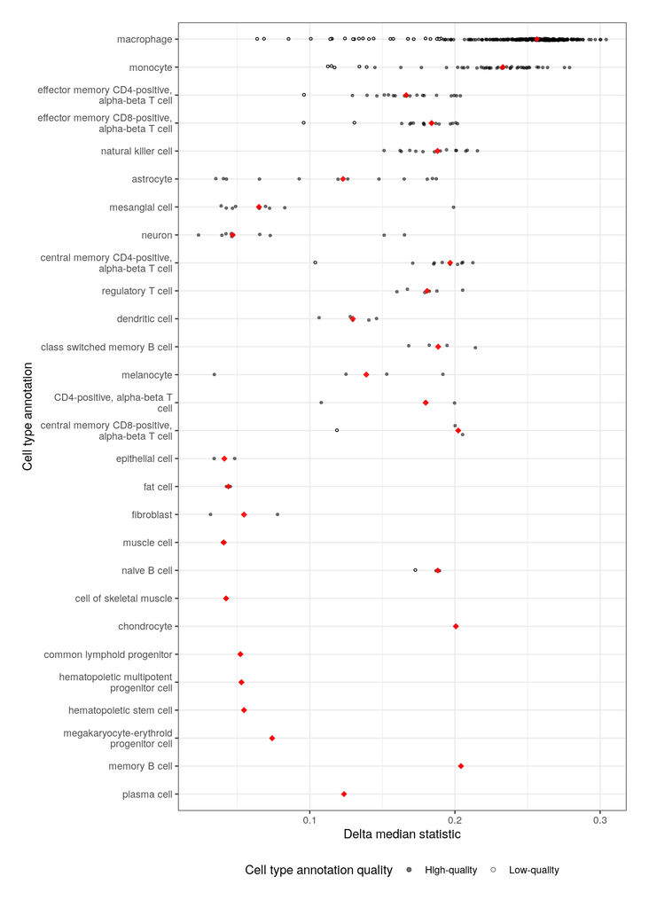

## `CellAssign` annotations

To assess the quality of `CellAssign` cell type annotations, we consider the probability associated with the annotated cell type. These probabilities are provided directly by `CellAssign`:

- `CellAssign` first calculates the probability of each cell being annotated as each cell type present in the reference.
- `CellAssign` then annotates cells by selecting the cell type with the highest probability among all cell types considered.
- These probabilities range from 0 to 1, with larger values indicating greater confidence in a given cell type label. We therefore expect reliable labels to have values close to 1.

The plot below shows the distribution of `CellAssign`-calculated probabilities for the final cell type labels. Line segments represent individual values that comprise each distribution.

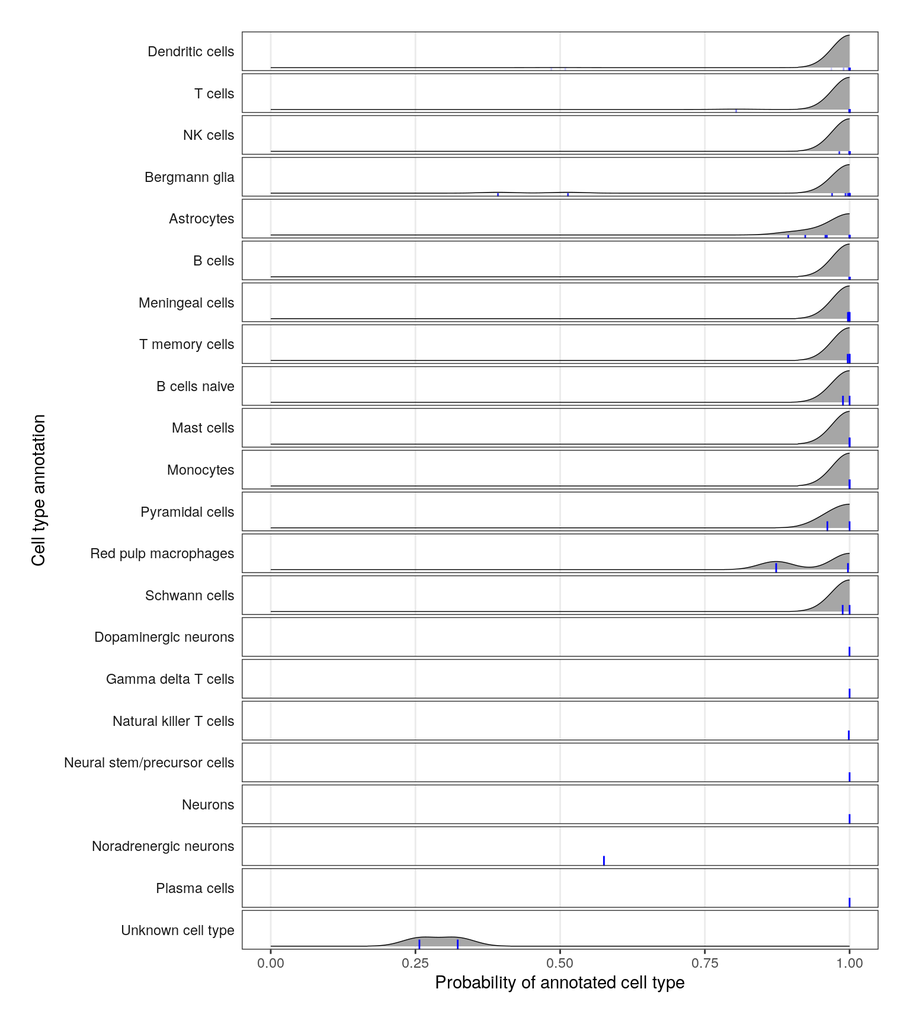